# Rock Lichen data from Sunset Crater

M.K. Lau

# Data Summary

- This is an analysis of the effect of Pinyon Pine tree traits on the saxicole (lichen and moss) community on rocks under the canopy of the trees.
- Trees were sampled in a pairwise design in which pairs were comprised of one tree that is susceptible to the herbivory of a stem boring moth (*Diorictria abietella*) and an adjacent tree that is resistant to the moth.
- As tree resistance to the moth is genetically based, pairwise sampling was conducted in order to isolate this genetic effect.
- Some trees that were sampled were dead, these trees were removed from the analysis.
- Plant data were observed by R. Michalet
  - Vegetation.xlsx
  - Light penetration.xls
  - light_&_litter(1).xls

# Main Results

- Rock epiphyte communities were adequately sampled, based on species accumulation curves, with moth resistant trees accumulating slightly more lichen species.
- Several tree variables, including light availability, leaf litter abundance and rock abundance, were impacted by moth susceptibility, creating strong differences in sub-canopy conditions.
- Saxicole community abundance, richness, diversity, composition were significantly, generally negatively, affected by moth herbivory.
- Correlation analysis supported an indirect link between genetically based moth susceptibility and impacts on lichen communities via decreasing rock (i.e. habitat) availability through increased leaf abscission and accumulation on rocks under trees.

# Analysis and Results

Analyses were conducted in the **R** statistical programming language. The following section loads dependencies and custom functions used in the analysis.

## Dependencies

```r
cran.pkgs <- c("reshape2", "vegan", "ecodist", "xtable", "knitr")

## install packages that are not installed
if (any(!(cran.pkgs %in% installed.packages()[, 1]))){
    sapply(cran.pkgs[which(!(cran.pkgs %in%
                             installed.packages()[, 1]))],
           install.packages,
           dependencies = TRUE,
           repos = 'http://cran.us.r-project.org')
}

## Load libraries
sapply(cran.pkgs, library, quietly = TRUE, character.only = TRUE)

## Custom Functions

## se: Calculate the standard error of a variable.
se <- function(x){sd(x) / sqrt(length(x))}
```

## Load Data

The following are variable descriptions (Variable, Type, Range, Definition):

- Moth,categorical,0 or 1,Was the tree susceptible (0) or resistant (1) to moth attack
- Live/Dead,categorical,0 or 1,Was the tree dead (0) or alive (1)
- Litter %,continuous,0 to 100,Percent cover inside quadrat
- Rocks > 3cm %,continuous,0 to 100,Percent cover of rocks > 3cm? inside quadrat
- Rocks < 3cm %,continuous,0 to 100,Percent cover of rocks < 3cm? inside quadrat
- Shrubs %,continuous,0 to 100,Percent cover of shrubs inside quadrat
- Grass %,continuous,0 to 100,Percent cover of grass inside quadrat
- Branches %,continuous,0 to 100,Percent cover of branches on ground inside quadrat
- Distance,continuous,0 to 100,“Distance from main trunk, converted to percent of crown radius at that azimuth”
- Azimuth,continuous,0 to 360,Compass direction from main trunk
- Slope,continuous,0 to 90,Topographical steepness
- Aspect,continuous,0 to 360,Compass direction of slope
- Light,continuous,,Amount of light available to epiliths

```r
## Data are in ../data/scrl
l.dat <- read.csv("./data/spp_env_combined.csv")

## Fix species names
colnames(l.dat)[colnames(l.dat) == "Acasup"] <- "Acaame"

## Summary of data
summary(l.dat)

## remove dead trees
l.dat <- l.dat[l.dat[, "Live.Dead"] != 0, ]

## Lichen species list
spp.l <- c("Acacon", "Acaame", "Acaobp", "Sterile.sp", "Brown.cr",
"Lobalp", "Canros", "Calare", "Phydub", "Rhichr", "Xanlin", "Xanpli",
"Xanele", "GrBr.cr", "Gray.cr")
spp.moss <- c("Synrur", "Cerpur.Bryarg")

## Create a community matrix
com <- l.dat[, colnames(l.dat) %in% c(spp.l, spp.moss)]
com.moss <- l.dat[, colnames(l.dat) %in% spp.moss]

## Add the tree labels to the rownames
rownames(com) <- paste(l.dat[, "Moth"], l.dat[, "Tree.pairs"], sep = "_")
rownames(com.moss) <- paste(l.dat[, "Moth"], l.dat[, "Tree.pairs"], sep = "_")
rownames(l.dat) <- paste(l.dat[, "Moth"], l.dat[, "Tree.pairs"], sep = "_")

## Paired environmental differences
total.rocks  <- apply(l.dat[, c("Big.rocks..", "Small.rocks..")], 1, sum)
env <- l.dat[, c("Litter..", "Big.rocks..", "Small.rocks..",
                           "Shrubs..", "Grass..", "Branches..",
                           "Light...N", "Light...S", "Light...average")]
env <- cbind(env, total.rocks)
env.dif <- apply(env, 2, function(x, p) tapply(x, p, diff), p = l.dat[, "Tree.pairs"])
```

## Saxicole communities were sufficiently sampled

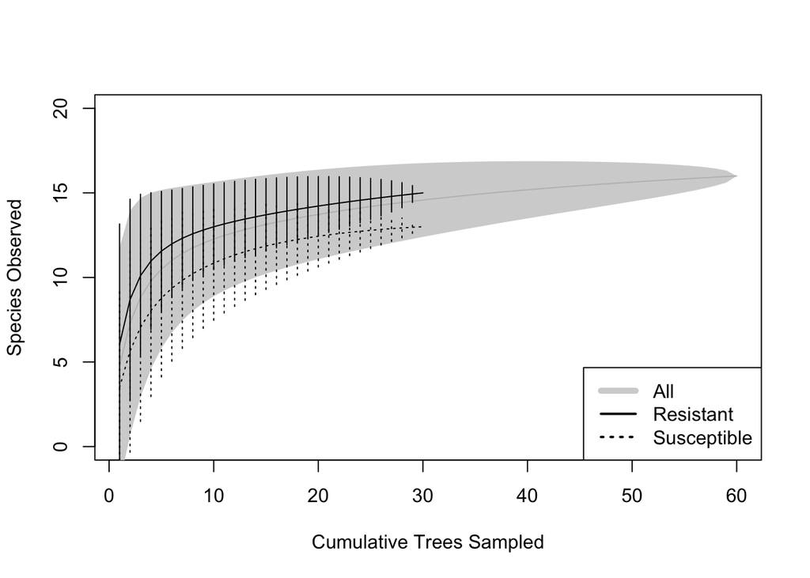

```r
spa.all <- specaccum(com, method = "exact")
spa.res <- specaccum(com[l.dat[, "Moth"] == 1, ], method = "exact")
spa.sus <- specaccum(com[l.dat[, "Moth"] == 0, ], method = "exact")

plot(spa.all,
     ylim = c(0, 20),
     xlab = "Cumulative Trees Sampled",
     ylab = "Species Observed",
     col = "grey", ci.col = 'lightgrey', ci.type = "poly", ci.lty = 0)
plot(spa.res, ci.col = "black", ci.type = "bar", lty = 1, add = TRUE, ci.lty = 1)
plot(spa.sus, ci.col = "black", ci.type = "bar", lty = 3, add = TRUE, ci.lty = 3)
legend("bottomright",
       legend = c("All", "Resistant", "Susceptible"),
       lty = c(1, 1, 3), lwd = c(5, 2, 2), col = c("lightgrey", "black", "black"))
```

```r
pdf("./results/scrl_spp-accum.pdf", width = 5, height = 5)
plot(spa.all,
     ylim = c(0, 20),
     xlab = "Cumulative Trees Sampled",
     ylab = "Species Observed",
     col = "grey", ci.col = 'lightgrey', ci.type = "poly", ci.lty = 0)
plot(spa.res, ci.col = "black", ci.type = "bar", lty = 1, add = TRUE, ci.lty = 1)
plot(spa.sus, ci.col = "black", ci.type = "bar", lty = 3, add = TRUE, ci.lty = 3)
legend("bottomright",
       legend = c("All", "Resistant", "Susceptible"),
       lty = c(1, 1, 3), lwd = c(5, 2, 2), col = c("lightgrey", "black", "black"))
dev.off()
```

## Moth trees have different microenvironments

```r
env.test.l <- apply(env.dif, 2, t.test)
env.test.l <- lapply(env.test.l, unlist)
env.test.tab <- do.call(rbind, env.test.l)
env.test.tab <- env.test.tab[, c(1, 2, 3, 6, 4, 5)]
env.test.tab <- apply(env.test.tab, 2, as.numeric)
rownames(env.test.tab) <- names(env.test.l)
colnames(env.test.tab) <- c("t", "df", "p-value", "Mean Difference", "Lower CI 95%", "Upper CI 95%")
kable(env.test.tab, digits = 4)
```

|  | t | df | p-value | Mean Difference | Lower CI 95% | Upper CI 95% |
| --- | --- | --- | --- | --- | --- | --- |
| Litter.. | 2.8665 | 29 | 0.0077 | 15.0700 | 4.3178 | 25.8222 |
| Big.rocks.. | -2.4617 | 29 | 0.0200 | -9.6837 | -17.7289 | -1.6384 |
| Small.rocks.. | -2.0792 | 29 | 0.0466 | -4.9750 | -9.8688 | -0.0812 |
| Shrubs.. | -1.7605 | 29 | 0.0889 | -0.5147 | -1.1126 | 0.0832 |
| Grass.. | -1.0000 | 29 | 0.3256 | -0.0493 | -0.1502 | 0.0516 |
| Branches.. | 1.0000 | 29 | 0.3256 | 0.1420 | -0.1484 | 0.4324 |
| Light…N | -8.0191 | 29 | 0.0000 | -15.9767 | -20.0514 | -11.9019 |
| Light…S | -7.5187 | 29 | 0.0000 | -14.2900 | -18.1772 | -10.4028 |
| Light…average | -9.2728 | 29 | 0.0000 | -15.1333 | -18.4712 | -11.7955 |
| total.rocks | -2.8178 | 29 | 0.0086 | -14.6587 | -25.2983 | -4.0190 |

## Moth trees have different lichen communities

```r
abun <- apply(com, 1, sum)
rich <- apply(com, 1, function(x) sum(sign(x)))
shan <- apply(com, 1, diversity, index = "shannon")
tt.a <- t.test(tapply(abun, l.dat[, "Tree.pairs"], diff))
tt.r <- t.test(tapply(rich, l.dat[, "Tree.pairs"], diff))
tt.h <- t.test(tapply(shan, l.dat[, "Tree.pairs"], diff))
tt.arh <- do.call(rbind,
                  list(a = unlist(tt.a),
                       r = unlist(tt.r),
                       h = unlist(tt.h)))
tt.arh <- apply(tt.arh[, 1:6], 2, as.numeric)
ard.mu <- rbind(tapply(abun, l.dat[, "Moth"], mean),
                tapply(rich, l.dat[, "Moth"], mean),
                tapply(shan, l.dat[, "Moth"], mean))
ard.se <- rbind(tapply(abun, l.dat[, "Moth"], se),
                tapply(rich, l.dat[, "Moth"], se),
                tapply(shan, l.dat[, "Moth"], se))
ard.tab <- cbind(ard.mu[, "0"], ard.se[, "0"],
                 ard.mu[, "1"], ard.se[, "1"])
colnames(ard.tab) <- c("Susceptible - Mean", "Susceptible - SE",
                       "Resistant - Mean", "Resistant - SE")
rownames(ard.tab) <- c("Abundance", "Richness", "Diversity (Shannon)")
```

```r
kable(ard.tab, digits = 3)
```

|  | Susceptible - Mean | Susceptible - SE | Resistant - Mean | Resistant - SE |
| --- | --- | --- | --- | --- |
| Abundance | 1.210 | 0.351 | 2.754 | 0.567 |
| Richness | 3.500 | 0.542 | 6.033 | 0.662 |
| Diversity (Shannon) | 0.707 | 0.119 | 1.144 | 0.125 |

```r
kable(tt.arh, digits = 3)
```

| statistic.t | parameter.df | p.value | conf.int1 | conf.int2 | estimate.mean of x |
| --- | --- | --- | --- | --- | --- |
| -2.249 | 29 | 0.032 | -2.948 | -0.140 | -1.544 |
| -2.955 | 29 | 0.006 | -4.287 | -0.780 | -2.533 |
| -2.447 | 29 | 0.021 | -0.802 | -0.072 | -0.437 |

Composition is different (PERMANOVA, in text and supplement)

```r
com.ds <- cbind(com, ds = rep(0.0001, nrow(com)))
com.ds.rel <- apply(com, 2, function(x) x/max(x))
com.ds.rel <- cbind(com.ds.rel, ds = rep(0.0001, nrow(com)))
com.ds.rel[is.na(com.ds.rel)] <- 0

set.seed(123)
ptab.moth <- adonis2(com.ds~ Moth, data = l.dat,
                    strata = l.dat[, "Tree.pairs"],
                    by = "margin", nperm = 100000)
set.seed(123)
ptab.moth.rel <- adonis2(com.ds.rel ~ Moth, data = l.dat,
                         strata = l.dat[, "Tree.pairs"],
                         by = "margin", nperm = 100000)

kable(ptab.moth)
```

|  | Df | SumOfSqs | R2 | F | Pr(>F) |
| --- | --- | --- | --- | --- | --- |
| Moth | 1 | 0.8329281 | 0.0389768 | 2.352343 | 0.023 |
| Residual | 58 | 20.5368939 | 0.9610232 | NA | NA |
| Total | 59 | 21.3698219 | 1.0000000 | NA | NA |

```r
kable(ptab.moth.rel)
```

|  | Df | SumOfSqs | R2 | F | Pr(>F) |
| --- | --- | --- | --- | --- | --- |
| Moth | 1 | 0.8791695 | 0.0405034 | 2.448363 | 0.021 |
| Residual | 58 | 20.8269063 | 0.9594966 | NA | NA |
| Total | 59 | 21.7060758 | 1.0000000 | NA | NA |

three main species were reduced by moths (FDR paired t-tests, in text + supplement)

```r
ind.spp <- apply(com, 2, function(x, p) t.test(tapply(x, p, diff)), p = l.dat[, "Tree.pairs"])
isp <- apply(do.call(rbind, lapply(ind.spp, unlist)), 2, as.numeric)
rownames(isp) <- names(ind.spp)
isp[, "p.value"] <- p.adjust(isp[, "p.value"], method = "fdr")
isp.all <- isp[, !(apply(isp, 2, function(x) all(is.na(x))))]
isp <- isp[order(isp[, "p.value"]), ]
```

```r
isp.all <- isp.all[, c(1, 2, 3, 6, 4, 5)]
colnames(isp.all) <- c("t", "df", "p-value", "Mean Difference", "Lower CI 95%", "Upper CI 95%")
kable(isp.all, digits = 4)
```

|  | t | df | p-value | Mean Difference | Lower CI 95% | Upper CI 95% |
| --- | --- | --- | --- | --- | --- | --- |
| Acacon | -3.3776 | 29 | 0.0159 | -0.0447 | -0.0717 | -0.0176 |
| Acaame | -3.2421 | 29 | 0.0159 | -0.1607 | -0.2620 | -0.0593 |
| Acaobp | -1.0747 | 29 | 0.4341 | -0.2860 | -0.8303 | 0.2583 |
| Sterile.sp | -1.0000 | 29 | 0.4341 | -0.0020 | -0.0061 | 0.0021 |
| Brown.cr | NaN | 29 | NaN | 0.0000 | NaN | NaN |
| Lobalp | -2.0414 | 29 | 0.2016 | -0.0047 | -0.0093 | 0.0000 |
| Canros | -3.5819 | 29 | 0.0159 | -0.3837 | -0.6027 | -0.1646 |
| Calare | -1.6076 | 29 | 0.2563 | -0.0307 | -0.0697 | 0.0083 |
| Phydub | -1.9226 | 29 | 0.2061 | -0.1053 | -0.2174 | 0.0067 |
| Rhichr | -1.5803 | 29 | 0.2563 | -0.2310 | -0.5300 | 0.0680 |
| Xanlin | -0.6170 | 29 | 0.6672 | -0.2267 | -0.9781 | 0.5247 |
| Xanpli | -0.2598 | 29 | 0.8500 | -0.0277 | -0.2455 | 0.1901 |
| Xanele | -1.5662 | 29 | 0.2563 | -0.0473 | -0.1091 | 0.0145 |
| GrBr.cr | 1.0000 | 29 | 0.4341 | 0.0013 | -0.0014 | 0.0041 |
| Gray.cr | 0.1093 | 29 | 0.9137 | 0.0003 | -0.0059 | 0.0066 |
| Synrur | 0.3628 | 29 | 0.8221 | 0.0220 | -0.1020 | 0.1460 |
| Cerpur.Bryarg | -1.2357 | 29 | 0.4027 | -0.0173 | -0.0460 | 0.0114 |

```r
write.csv(round(isp.all, 5), file = "results/scrl_isp_table.csv")
```

Calculate the average abundances of the indicators

```r
isp.names <- as.character(na.omit(rownames(isp[isp[, "p.value"] < 0.05, ])))
isp.com <- com[,colnames(com) %in% isp.names]
isp.dif <- apply(isp.com, 2, function(x,y) tapply(x, y, diff), y = l.dat[ ,"Tree.pairs"])
```

Create a multi-bar plot figure for the community.

```r
isp.dat <- melt(isp.dif)
colnames(isp.dat) <- c("Tree.pairs", "Species", "diff")
isp.mu <- tapply(isp.dat[, "diff"], isp.dat[, "Species"], mean)
isp.se <- tapply(isp.dat[, "diff"], isp.dat[, "Species"], se)
ard.dif <- cbind(tapply(abun, l.dat[, "Tree.pairs"], diff),
                 tapply(rich, l.dat[, "Tree.pairs"], diff),
                 tapply(shan, l.dat[, "Tree.pairs"], diff))
colnames(ard.dif) <- c("Abundance", "Richness", "Diversity")
ard.dat <- melt(ard.dif)
colnames(ard.dat) <- c("Tree.pairs", "Stat", "diff")
ard.mu <- tapply(ard.dat[, "diff"], ard.dat[, "Stat"], mean)
ard.se <- tapply(ard.dat[, "diff"], ard.dat[, "Stat"], se)

pdf(file = "./results/scrl_isp_ard.pdf", width = 9, height = 5)

par(mfrow = c(1,2))
bp.out <- barplot(ard.mu, col = "darkgrey", ylim = c(-5, 0),
                  ylab = "Difference (S - R)", border = "NA")
segments(bp.out[, 1], ard.mu + ard.se,
         bp.out[, 1], ard.mu - ard.se,
         lwd = 1.5)
bp.out <- barplot(isp.mu, col = "darkgrey", ylim = c(-0.5, 0),
                  ylab = "Difference (S - R)", border = "NA",
            axisnames = TRUE,
            names.arg = sapply(names(isp.mu),
                function(x)
                                    paste(c(substr(x, 1, 1),
                                            substr(x, 4, 4)), collapse = "")))
segments(bp.out[, 1], isp.mu + isp.se,
         bp.out[, 1], isp.mu - isp.se,
         lwd = 1.5)
dev.off()
```

Create a plot of the two most indicative species

```r
pdf(file = "./results/scrl_complot.pdf", width = 7, height = 7)
plot(com[, c("Acaame", "Canros")], pch = l.dat[, "Moth"] + 1, cex = 3, col = l.dat[, "Moth"] + 1)
legend("topleft", title = "Tree Type", legend = c("Resistant", "Susceptible"), pch = c(2, 1), col = c(2, 1))
dev.off()
```

Create plot with indicator taxa

```r
pdf(file = "./results/scrl_pdif.pdf", width = 7, height = 7)
plot(melt(isp.dif)[-1], xlab = "Species", ylab = "Abundance Reduction")
dev.off()
```

## Litter covering rocks was the main driver

Although light did significantly explain variation in the lichen community, this was not significant once the variation in litter was controlled for.

There was high correlation among environmental variables.

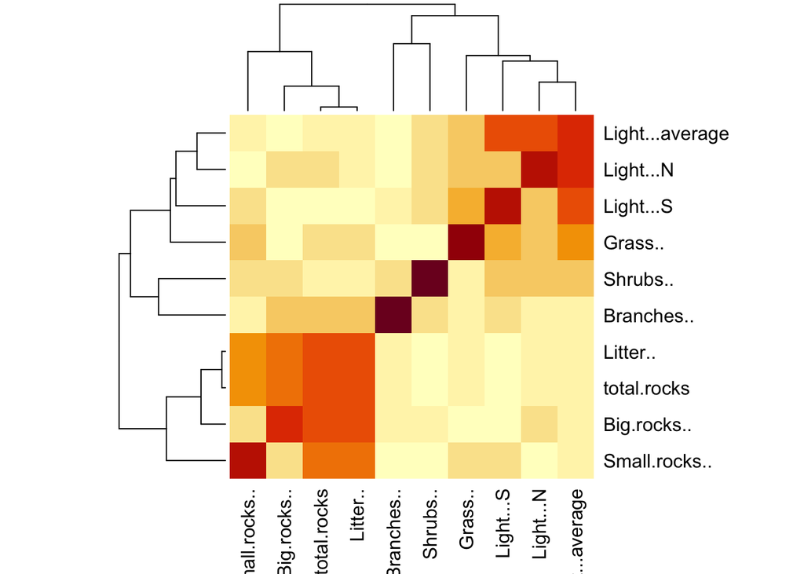

```r
heatmap(abs(round(cor(env.dif), 3)))
```

```r
set.seed(123)
ptab.env <- adonis2(com.ds ~ Litter.. +  Light...average, data = l.dat,
                   strata = l.dat[, "Tree.pairs"],
                   by = "margin", nperm = 100000)
kable(ptab.env)
```

|  | Df | SumOfSqs | R2 | F | Pr(>F) |
| --- | --- | --- | --- | --- | --- |
| Litter.. | 1 | 1.0035484 | 0.0469610 | 2.972456 | 0.007 |
| Light…average | 1 | 0.4114619 | 0.0192543 | 1.218728 | 0.243 |
| Residual | 57 | 19.2441042 | 0.9005271 | NA | NA |
| Total | 59 | 21.3698219 | 1.0000000 | NA | NA |

```r
set.seed(123)
ptab.env <- adonis2(com.ds ~ Light...average + Litter.. , data = l.dat,
                   strata = l.dat[, "Tree.pairs"],
                   by = "margin", nperm = 100000)
kable(ptab.env)
```

|  | Df | SumOfSqs | R2 | F | Pr(>F) |
| --- | --- | --- | --- | --- | --- |
| Light…average | 1 | 0.4114619 | 0.0192543 | 1.218728 | 0.243 |
| Litter.. | 1 | 1.0035484 | 0.0469610 | 2.972456 | 0.007 |
| Residual | 57 | 19.2441042 | 0.9005271 | NA | NA |
| Total | 59 | 21.3698219 | 1.0000000 | NA | NA |

```r
set.seed(123)
ptab.env <- adonis2(com.ds ~ total.rocks ,
                   strata = l.dat[, "Tree.pairs"],
                   by = "term", nperm = 100000)

kable(ptab.env)
```

|  | Df | SumOfSqs | R2 | F | Pr(>F) |
| --- | --- | --- | --- | --- | --- |
| total.rocks | 1 | 1.664876 | 0.0779078 | 4.900435 | 0.002 |
| Residual | 58 | 19.704946 | 0.9220922 | NA | NA |
| Total | 59 | 21.369822 | 1.0000000 | NA | NA |

```r
set.seed(123)
ptab.env <- adonis2(com.ds ~ Big.rocks.. , data = l.dat,
                   strata = l.dat[, "Tree.pairs"],
                   by = "term", nperm = 100000)

kable(ptab.env)
```

|  | Df | SumOfSqs | R2 | F | Pr(>F) |
| --- | --- | --- | --- | --- | --- |
| Big.rocks.. | 1 | 2.428473 | 0.1136403 | 7.436188 | 0.001 |
| Residual | 58 | 18.941349 | 0.8863597 | NA | NA |
| Total | 59 | 21.369822 | 1.0000000 | NA | NA |

```r
set.seed(123)
ptab.env <- adonis2(com.ds ~ Small.rocks.. , data = l.dat,
                   strata = l.dat[, "Tree.pairs"],
                   by = "term", nperm = 100000)
kable(ptab.env)
```

|  | Df | SumOfSqs | R2 | F | Pr(>F) |
| --- | --- | --- | --- | --- | --- |
| Small.rocks.. | 1 | 0.2204425 | 0.0103156 | 0.604541 | 0.782 |
| Residual | 58 | 21.1493794 | 0.9896844 | NA | NA |
| Total | 59 | 21.3698219 | 1.0000000 | NA | NA |

```r
set.seed(123)
ptab.env <- adonis2(com.ds ~ Litter.. , data = l.dat,
                   strata = l.dat[, "Tree.pairs"],
                   by = "term", nperm = 100000)
kable(ptab.env)
```

|  | Df | SumOfSqs | R2 | F | Pr(>F) |
| --- | --- | --- | --- | --- | --- |
| Litter.. | 1 | 1.714256 | 0.0802185 | 5.058457 | 0.002 |
| Residual | 58 | 19.655566 | 0.9197815 | NA | NA |
| Total | 59 | 21.369822 | 1.0000000 | NA | NA |

```r
cor.test(env.dif[, "Big.rocks.."], env.dif[, "Litter.."])
```

```
##
##  Pearson's product-moment correlation
##
## data:  env.dif[, "Big.rocks.."] and env.dif[, "Litter.."]
## t = -11.106, df = 28, p-value = 9.054e-12
## alternative hypothesis: true correlation is not equal to 0
## 95 percent confidence interval:
##  -0.9530598 -0.8039735
## sample estimates:
##        cor
## -0.9027609
```

```r
pdf("./results/scrl_litterVbigrocks.pdf", width = 5, height = 5)
dev.off()
```

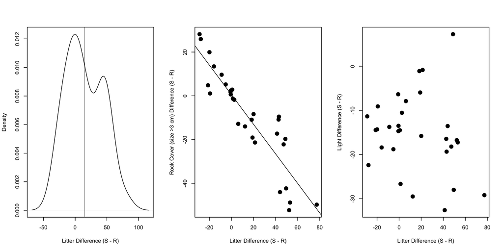

```r
par(mfrow = c(1,3))
plot(density(tapply(l.dat[, "Litter.."], l.dat[, "Tree.pairs"], diff)),
    main = "", xlab = "Litter Difference (S - R)")
abline(v = mean(tapply(l.dat[, "Litter.."], l.dat[, "Tree.pairs"], diff)),
    lwd = 0.5)
plot(env.dif[, "Big.rocks.."] ~ env.dif[, "Litter.."],
     xlab = "Litter Difference (S - R)", ylab = "Rock Cover (size >3 cm) Difference (S - R)",
     pch = 19, cex = 1.5)
abline(lm(env.dif[, "Big.rocks.."] ~ env.dif[, "Litter.."]))
plot(tapply(l.dat[, "Litter.."], l.dat[, "Tree.pairs"], diff),
    tapply(l.dat[, "Light...average"], l.dat[, "Tree.pairs"], diff),
    xlab = "Litter Difference (S - R)", ylab = "Light Difference (S - R)",
    pch = 19, cex = 1.5)
```

```r
pdf("./results/scrl_litter_effects.pdf", width = 10, height = 5)
par(mfrow = c(1,3))
plot(density(tapply(l.dat[, "Litter.."], l.dat[, "Tree.pairs"], diff)),
    main = "", xlab = "Litter Difference (S - R)")
abline(v = mean(tapply(l.dat[, "Litter.."], l.dat[, "Tree.pairs"], diff)),
    lwd = 0.5)
plot(env.dif[, "Big.rocks.."] ~ env.dif[, "Litter.."],
     xlab = "Litter Difference (S - R)", ylab = "Rock Cover (size >3 cm) Difference (S - R)",
     pch = 19, cex = 1.5)
abline(lm(env.dif[, "Big.rocks.."] ~ env.dif[, "Litter.."]))
plot(tapply(l.dat[, "Litter.."], l.dat[, "Tree.pairs"], diff),
    tapply(l.dat[, "Light...average"], l.dat[, "Tree.pairs"], diff),
    xlab = "Litter Difference (S - R)", ylab = "Light Difference (S - R)",
    pch = 19, cex = 1.5)
dev.off()
```

```r
nmds.out <- nmds(vegdist(com.ds), 2, 2)
ord <- nmds.min(nmds.out, dims = 2)
```

```
## Minimum stress for given dimensionality:  0.2169355
## r^2 for minimum stress configuration:  0.6416469
```

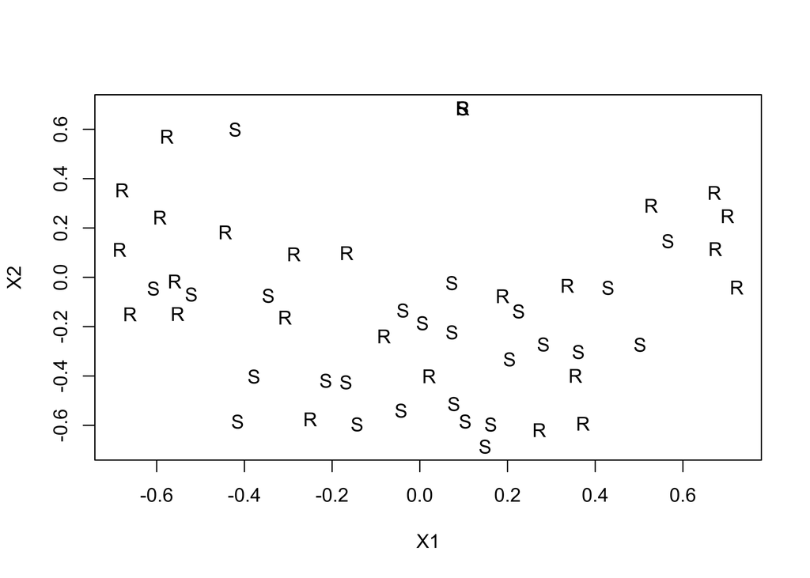

```r
ord.pch <- c("R", "S")[(l.dat[, "Moth"] + 1)]
plot(X2~ X1, data = ord, pch = ord.pch)
```

Litter not light was correlated with large rocks (dist cor, in text). Thus, higher amounts of litter under trees was not related to the penetration of light under the tree canopy.

```r
cor.test(tapply(l.dat[, "Big.rocks.."], l.dat[, "Tree.pairs"], diff),
         tapply(l.dat[, "Litter.."], l.dat[, "Tree.pairs"], diff))
```

```
##
##  Pearson's product-moment correlation
##
## data:  tapply(l.dat[, "Big.rocks.."], l.dat[, "Tree.pairs"], diff) and tapply(l.dat[, "Litter.."], l.dat[, "Tree.pairs"], diff)
## t = -11.106, df = 28, p-value = 9.054e-12
## alternative hypothesis: true correlation is not equal to 0
## 95 percent confidence interval:
##  -0.9530598 -0.8039735
## sample estimates:
##        cor
## -0.9027609
```

```r
cor.test(tapply(l.dat[, "Big.rocks.."], l.dat[, "Tree.pairs"], diff),
         tapply(l.dat[, "Light...average"], l.dat[, "Tree.pairs"], diff))
```

```
##
##  Pearson's product-moment correlation
##
## data:  tapply(l.dat[, "Big.rocks.."], l.dat[, "Tree.pairs"], diff) and tapply(l.dat[, "Light...average"], l.dat[, "Tree.pairs"], diff)
## t = 0.71624, df = 28, p-value = 0.4798
## alternative hypothesis: true correlation is not equal to 0
## 95 percent confidence interval:
##  -0.2376184  0.4716125
## sample estimates:
##       cor
## 0.1341335
```

```r
cor.test(tapply(l.dat[, "Litter.."], l.dat[, "Tree.pairs"], diff),
         tapply(l.dat[, "Light...average"], l.dat[, "Tree.pairs"], diff))
```

```
##
##  Pearson's product-moment correlation
##
## data:  tapply(l.dat[, "Litter.."], l.dat[, "Tree.pairs"], diff) and tapply(l.dat[, "Light...average"], l.dat[, "Tree.pairs"], diff)
## t = -0.92053, df = 28, p-value = 0.3652
## alternative hypothesis: true correlation is not equal to 0
## 95 percent confidence interval:
##  -0.5007401  0.2013096
## sample estimates:
##        cor
## -0.1713898
```

```r
cor.test(tapply(l.dat[, "Small.rocks.."], l.dat[, "Tree.pairs"], diff),
         tapply(l.dat[, "Litter.."], l.dat[, "Tree.pairs"], diff))
```

```
##
##  Pearson's product-moment correlation
##
## data:  tapply(l.dat[, "Small.rocks.."], l.dat[, "Tree.pairs"], diff) and tapply(l.dat[, "Litter.."], l.dat[, "Tree.pairs"], diff)
## t = -4.994, df = 28, p-value = 2.819e-05
## alternative hypothesis: true correlation is not equal to 0
## 95 percent confidence interval:
##  -0.8391386 -0.4332285
## sample estimates:
##        cor
## -0.6863699
```

# Vegetation Analysis

## From Richard Michalet

> First sheet is the vegetation matrix with all relevés.

> Second sheet are values of vegetation cover, rock cover and species richness in all replicates of all treatments + mean values of treatments and corresponding graphs.

> From what I remember the methods were simple, quadrats of 1square meter in four treatments with a full factorial design, exposure (north and south of the tree), mortality (alive vs dead shrubs), tree susceptibility (resistant vs susceptible) and tree presence (below the canopy or outside the canopy in open conditions at the close vicinity of the trees).

> You can see that without stats results are obvious: strong effect of tree susceptibility only below the tree and in both exposure for both alive and dead trees.

```r
library(readxl)

veg <- readxl::read_xlsx("data/Vegetation.xlsx")
veg <- as.data.frame(veg)
l.raw <- read.csv("data/rawdata Sunset Crater for Matt.csv")
l.raw <- l.raw[!(grepl("cover", l.raw[,1])),]
le.raw <- read.csv("data/rawdata Sunset Crater for Matt_env.csv")
le.raw <- le.raw[!(grepl("cover", le.raw[,1])),]
le.raw <- na.omit(le.raw)
```

## Observation checks

Do the saxicole community and environment data match?

```
## [1] TRUE
```

Are all of the trees in the saxicole dataset represented in the veg dataset?

```
## [1] TRUE
```

## Coalesce datasets

```r
l.d <- data.frame(le.raw[, -2:-3], l.raw[, -1:-3])
l.d <- split(l.d, l.d[, "Tree.ID"])
l.d <- l.d[names(l.d) %in% le.raw[, "Tree.ID"]]
l.d <- lapply(l.d, function(x) x[, -1])
l.d <- lapply(l.d, apply, 2, mean)
l.df <- do.call(rbind, l.d)
trt <- strsplit(rownames(l.df), "")
moth.alive <- lapply(trt, function(x) x[x %in% c(letters, LETTERS)][1:2])
moth.alive <- do.call(rbind, moth.alive)
tree <- lapply(trt, function(x) x[x %in% 0:9])
tree <- as.numeric(unlist(lapply(tree, paste, collapse = "")))
l.df <- data.frame(Tree.pairs = tree,
                   Moth = moth.alive[, 1],
                   Live.Dead = moth.alive[, 2],
                   l.df)
l.df <- l.df[l.df[, "Live.Dead"] == "A", ]
l.df[, "Moth"] <- as.character(l.df[, "Moth"])
l.df[l.df[, "Moth"] == "R", "Moth"] <- 1
l.df[l.df[, "Moth"] == "S", "Moth"] <- 0
moth.tree <- paste(l.df[, "Moth"], l.df[, "Tree.pairs"], sep = "_")
l.df <- l.df[match(rownames(l.dat), moth.tree), ]
```

Check that `l.dat` and `l.df` are correctly coalesced:

```
## [1] TRUE
```

[output not shown]

Check that the values of the variables match, excluding light:

Checking the vegetation and rock cover correlations. We find that vegetation cover is is significantly, but not strongly correlated with rock cover. Large rock cover measurements in the saxicole dataset is strongly correlated with total rock cover in the plant dataset.

Both vegetation and rock cover are strongly affected by moth susceptibility.

```r
cor.test(v.dat[, "Vegetation.cover"], v.dat[, "Rock.cover"], alt = "greater")
```

```
##
##  Pearson's product-moment correlation
##
## data:  v.dat[, "Vegetation.cover"] and v.dat[, "Rock.cover"]
## t = 1.8835, df = 58, p-value = 0.03233
## alternative hypothesis: true correlation is greater than 0
## 95 percent confidence interval:
##  0.0269872 1.0000000
## sample estimates:
##       cor
## 0.2400809
```

```r
cor.test(l.dat[, "Big.rocks.."], v.dat[, "Rock.cover"], alt = "greater")
```

```
##
##  Pearson's product-moment correlation
##
## data:  l.dat[, "Big.rocks.."] and v.dat[, "Rock.cover"]
## t = 9.5342, df = 58, p-value = 8.816e-14
## alternative hypothesis: true correlation is greater than 0
## 95 percent confidence interval:
##  0.6809688 1.0000000
## sample estimates:
##       cor
## 0.7813334
```

```r
t.test(tapply(v.dat[, "Rock.cover"], v.dat[, "Tree.Pair"], diff))
```

```
##
##  One Sample t-test
##
## data:  tapply(v.dat[, "Rock.cover"], v.dat[, "Tree.Pair"], diff)
## t = -3.3582, df = 29, p-value = 0.002208
## alternative hypothesis: true mean is not equal to 0
## 95 percent confidence interval:
##  -27.621617  -6.711716
## sample estimates:
## mean of x
## -17.16667
```

```r
t.test(tapply(v.dat[, "Vegetation.cover"], v.dat[, "Tree.Pair"], diff))
```

```
##
##  One Sample t-test
##
## data:  tapply(v.dat[, "Vegetation.cover"], v.dat[, "Tree.Pair"], diff)
## t = -7.2026, df = 29, p-value = 6.269e-08
## alternative hypothesis: true mean is not equal to 0
## 95 percent confidence interval:
##  -28.67505 -15.99162
## sample estimates:
## mean of x
## -22.33333
```

Both plant richness and Shannon’s Diversity index were significantly affected by moth susceptibility.

```r
v.rich <- apply(v.com, 1, function(x) sum(sign(x)))
v.shan <- apply(v.com, 1, diversity)

t.test(tapply(v.rich, l.dat[, "Tree.pairs"], diff))
```

```
##
##  One Sample t-test
##
## data:  tapply(v.rich, l.dat[, "Tree.pairs"], diff)
## t = -7.477, df = 29, p-value = 3.062e-08
## alternative hypothesis: true mean is not equal to 0
## 95 percent confidence interval:
##  -1.6555988 -0.9444012
## sample estimates:
## mean of x
##      -1.3
```

```r
t.test(tapply(v.shan, l.dat[, "Tree.pairs"], diff))
```

```
##
##  One Sample t-test
##
## data:  tapply(v.shan, l.dat[, "Tree.pairs"], diff)
## t = -4.2192, df = 29, p-value = 0.00022
## alternative hypothesis: true mean is not equal to 0
## 95 percent confidence interval:
##  -0.4386895 -0.1522394
## sample estimates:
##  mean of x
## -0.2954645
```

This is a multivariate analysis of the plant community response to moth susceptibility (PERMANOVA). This analysis uses a modified Bray-Curtis Dissimilarity metric, which permits the inclusion of quadrats that had no plants in them. The analysis also accounts for the paired structure of the data (i.e. pairs of moth susceptible and resistant trees).

```r
set.seed(123)
ptab.v.moth <- adonis2(v.com.ds ~ Moth, data = l.dat,
                    strata = v.dat[, "Tree.pairs"],
                    by = "margin", nperm = 100000)
set.seed(123)
ptab.v.moth.rel <- adonis2(v.com.ds.rel ~ Moth, data = l.dat,
                         strata = v.dat[, "Tree.pairs"],
                         by = "margin", nperm = 100000)
```

Here are the results of the multivariate plant community response.

PERMANOVA of plant community response to moth.

|  | Df | SumOfSqs | R2 | F | Pr(>F) |
| --- | --- | --- | --- | --- | --- |
| Moth | 1 | 5.174376 | 0.3081168 | 25.82917 | 0.001 |
| Residual | 58 | 11.619181 | 0.6918832 | NA | NA |
| Total | 59 | 16.793557 | 1.0000000 | NA | NA |

Here are the results of the multivariate plant community response after relativizing by species max.

PERMANOVA of relativized plant community response to moth.

|  | Df | SumOfSqs | R2 | F | Pr(>F) |
| --- | --- | --- | --- | --- | --- |
| Moth | 1 | 5.989174 | 0.288048 | 23.46617 | 0.001 |
| Residual | 58 | 14.803100 | 0.711952 | NA | NA |
| Total | 59 | 20.792275 | 1.000000 | NA | NA |

Do light, litter or rock cover influence plant communities?

```r
set.seed(123)
ptab.v.env <- adonis2(v.com.ds ~ Light...average + Litter.. + Big.rocks..,
                      data = l.dat,
                      strata = l.dat[, "Tree.pairs"],
                      by = "margin", nperm = 100000)
set.seed(123)
ptab.v.env.rel <- adonis2(v.com.ds.rel ~ Light...average + Litter.. + Big.rocks..,
                          data = l.dat,
                          strata = l.dat[, "Tree.pairs"],
                          by = "margin", nperm = 100000)
```

Light has a strong effect on the plant community. Litter also has an effect but it is small and marginally significant, either un-relativized or relativized, respectively.

PERMANOVA of plant community response to several environmental variables.

|  | Df | SumOfSqs | R2 | F | Pr(>F) |
| --- | --- | --- | --- | --- | --- |
| Light…average | 1 | 2.8692870 | 0.1708564 | 12.696810 | 0.001 |
| Litter.. | 1 | 0.6890028 | 0.0410278 | 3.048889 | 0.049 |
| Big.rocks.. | 1 | 0.3621592 | 0.0215654 | 1.602582 | 0.189 |
| Residual | 56 | 12.6551530 | 0.7535719 | NA | NA |
| Total | 59 | 16.7935571 | 1.0000000 | NA | NA |

PERMANOVA of relativized plant community response to several environmental variables.

|  | Df | SumOfSqs | R2 | F | Pr(>F) |
| --- | --- | --- | --- | --- | --- |
| Light…average | 1 | 3.2173963 | 0.1547400 | 11.469106 | 0.001 |
| Litter.. | 1 | 0.7307945 | 0.0351474 | 2.605075 | 0.061 |
| Big.rocks.. | 1 | 0.5197916 | 0.0249993 | 1.852910 | 0.138 |
| Residual | 56 | 15.7095234 | 0.7555462 | NA | NA |
| Total | 59 | 20.7922745 | 1.0000000 | NA | NA |

```r
set.seed(123)
ptab.v.env.seq <- adonis2(v.com.ds ~ Light...average + Litter.. + Big.rocks..,
                      data = l.dat,
                      strata = l.dat[, "Tree.pairs"],
                      by = "term", nperm = 100000)
set.seed(123)
ptab.v.env.rel.seq <- adonis2(v.com.ds.rel ~ Light...average + Litter.. + Big.rocks..,
                          data = l.dat,
                          strata = l.dat[, "Tree.pairs"],
                          by = "term", nperm = 100000)
```

After controlling for the effect of light, the effect of litter is no longer significant, un-relatvizied or relativized, respectivley.

Sequential PERMANOVA of plant community response to several environmental variables. Variance is explained sequentially by factors entered into the model from top to bottom.

|  | Df | SumOfSqs | R2 | F | Pr(>F) |
| --- | --- | --- | --- | --- | --- |
| Light…average | 1 | 3.2765116 | 0.1951053 | 14.498809 | 0.001 |
| Litter.. | 1 | 0.4997333 | 0.0297574 | 2.211358 | 0.103 |
| Big.rocks.. | 1 | 0.3621592 | 0.0215654 | 1.602582 | 0.189 |
| Residual | 56 | 12.6551530 | 0.7535719 | NA | NA |
| Total | 59 | 16.7935571 | 1.0000000 | NA | NA |

Sequential PERMANOVA of relativized plant community response to several environmental variables. Variance is explained sequentially by factors entered into the model from top to bottom.

|  | Df | SumOfSqs | R2 | F | Pr(>F) |
| --- | --- | --- | --- | --- | --- |
| Light…average | 1 | 3.8762571 | 0.1864278 | 13.81776 | 0.001 |
| Litter.. | 1 | 0.6867025 | 0.0330268 | 2.44790 | 0.059 |
| Big.rocks.. | 1 | 0.5197916 | 0.0249993 | 1.85291 | 0.138 |
| Residual | 56 | 15.7095234 | 0.7555462 | NA | NA |
| Total | 59 | 20.7922745 | 1.0000000 | NA | NA |

- Indicator species

There are two species that are responding to moth susceptibility, Apache plume and *Asteraceae ovales*.

|  | t | df | p-value | Mean Difference | Lower CI 95% | Upper CI 95% |
| --- | --- | --- | --- | --- | --- | --- |
| Apache.plume | -4.6010 | 29 | 0.0007 | -10.2667 | -14.8304 | -5.7029 |
| Asteraceae.ovales | -3.9581 | 29 | 0.0020 | -8.1333 | -12.3360 | -3.9307 |
| Rhus.trilobata | -1.8410 | 29 | 0.1869 | -3.1667 | -6.6847 | 0.3514 |
| Rabbit.brush | -1.0000 | 29 | 0.3256 | -0.6667 | -2.0302 | 0.6968 |
| Avena | -1.7951 | 29 | 0.1869 | -0.2000 | -0.4279 | 0.0279 |
| Juniperus.monosperma | -1.0000 | 29 | 0.3256 | -0.1667 | -0.5075 | 0.1742 |
| Plante.grise.allongée | -1.0000 | 29 | 0.3256 | -0.1000 | -0.3045 | 0.1045 |
| Scarlet.glia | -1.0000 | 29 | 0.3256 | -0.0667 | -0.2030 | 0.0697 |
| Bouteloua.gracilis | NaN | 29 | NaN | 0.0000 | NaN | NaN |
| Pinus.edulis.S | NaN | 29 | NaN | 0.0000 | NaN | NaN |
| Stipa.A | NaN | 29 | NaN | 0.0000 | NaN | NaN |
| Stipa.B | NaN | 29 | NaN | 0.0000 | NaN | NaN |
| Stipa.très.grand | NaN | 29 | NaN | 0.0000 | NaN | NaN |
| Ephedra | NaN | 29 | NaN | 0.0000 | NaN | NaN |
| Grande.grass.corymbe | NaN | 29 | NaN | 0.0000 | NaN | NaN |
| Boraginacée.rosette.grise | NaN | 29 | NaN | 0.0000 | NaN | NaN |
| Grass.à.nœud | NaN | 29 | NaN | 0.0000 | NaN | NaN |
| Brachypode | NaN | 29 | NaN | 0.0000 | NaN | NaN |
| Carex | NaN | 29 | NaN | 0.0000 | NaN | NaN |
| Cactus | NaN | 29 | NaN | 0.0000 | NaN | NaN |
| Hordeum | NaN | 29 | NaN | 0.0000 | NaN | NaN |
| Chenopodiaceae | NaN | 29 | NaN | 0.0000 | NaN | NaN |
| Ribes | NaN | 29 | NaN | 0.0000 | NaN | NaN |
| Aster.grise | NaN | 29 | NaN | 0.0000 | NaN | NaN |
| Rosette.frisée | NaN | 29 | NaN | 0.0000 | NaN | NaN |
| Chamaephyte.gris | NaN | 29 | NaN | 0.0000 | NaN | NaN |
| Castilleja | NaN | 29 | NaN | 0.0000 | NaN | NaN |
| Opuntia | NaN | 29 | NaN | 0.0000 | NaN | NaN |
| Rubiaceae | NaN | 29 | NaN | 0.0000 | NaN | NaN |
| Andropogon | NaN | 29 | NaN | 0.0000 | NaN | NaN |
| Pinus.edulis.R | 1.0000 | 29 | 0.3256 | 0.3333 | -0.3484 | 1.0151 |

## Multivariate Correlation of Plants and Saxicoles

There is no significant multivariate correlation between the veg and saxicole communities, regardless of whether the community data are relativized. This is likely a result of the two communities responded to different variables with low correlation (i.e. rocks = saxicoles and light = plants). This was true either without or with relativization by species max.

```r
v.d <- vegdist(v.com.ds)
l.d <- vegdist(com.ds)

mantel(v.d ~ l.d)
```

```
##      mantelr        pval1        pval2        pval3    llim.2.5%   ulim.97.5%
## -0.002762319  0.513000000  0.488000000  0.914000000 -0.034504235  0.032707393
```

```r
v.d <- vegdist(v.com.ds.rel)
l.d <- vegdist(com.ds.rel)

mantel(v.d ~ l.d)
```

```
##     mantelr       pval1       pval2       pval3   llim.2.5%  ulim.97.5%
##  0.02328021  0.21200000  0.78900000  0.44300000 -0.01176642  0.05838093
```